# Lab 01 Basic of R, RStudio, and GitHub

## RE 519 Data Analytics and Visualization | Autumn 2025

2025-08-15

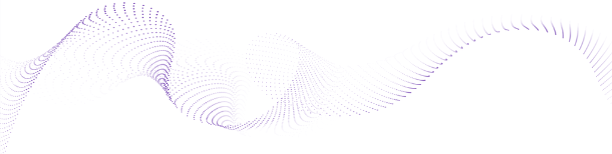

[Course Website](https://www.yuehaoyu.com/data-analytics-visualization/) | [Resources](https://www.yuehaoyu.com/data-analytics-visualization/resources/) | [Ed Discussion](https://www.yuehaoyu.com/data-analytics-visualization/ed/)

**Welcome to start the journey in data science!** Through this quarter, we will learn how to conduct data analysis and visualization using [R](http://www.r-project.org), [RStudio](https://posit.co/products/open-source/rstudio), and [Tableau](https://www.tableau.com). There are tons of resources, both online or within University of Washington, for you to start learning data science, check [resource page](https://www.yuehaoyu.com/data-analytics-visualization/resources/).

We will have **8** labs in total (2~3 classes for each lab) and you only need to submit **once** after each lab. The due day for each lab can be found on the [course wesbite](https://www.yuehaoyu.com/data-analytics-visualization/). The submission should include Rmd, html, and any other files required to rerun the codes.

Please check [grading policy of this class](https://www.yuehaoyu.com/data-analytics-visualization/syllabus/#course-requirements) in advance, including grade curving, late date policy, etc. **For Lab 1–3, the use of any generative AI tool (ChatGPT, Copilot, etc.) is prohibited**. We will run AI detection on each submission. More information about [Academic Integrity](https://www.yuehaoyu.com/data-analytics-visualization/syllabus/#academic-integrity) and [the Use of AI](https://www.yuehaoyu.com/data-analytics-visualization/syllabus/#use-of-ai).

## Lab 01-A: Setup

> Recommended Reading: [Appendix B, Modern Data Science with R, 3rd edition](https://mdsr-book.github.io/mdsr3e/B-appR.html)

### Why R and RStudio?

R is a programming language built for statistical computing. But, if one already knows Stata or similar software, why use R?

- R is *free*, so you don’t need a terminal server.
- R has a *very* large community.
- R can handle virtually any data format.
- R makes replication easy.
- R is a *language* so it can do *everything*.
- R skills transfer to other languages like [Python](https://www.python.org) and [Julia](https://julialang.org).

R Studio is a “front-end” or integrated development environment (IDE) for R that can make your life *easier*. We’ll show RStudio can…

- Organize your code, output, and plots
- Auto-complete code and highlight syntax
- Help view data and objects
- Enable easy integration of R code into documents with *R Markdown*
- Manage [`git`](https://git-scm.com) repositories
- Run interactive tutorials

### Selling you on R Markdown

The ability to create R Markdown files is a powerful advantage of R:

- Document analyses by combining text, code, and output
  - No copying and pasting into Word
  - Easy for collaborators to understand
  - Show as little or as much code as you want
- Produce many different document types as output
  - PDF documents
  - HTML webpages and reports
  - Word and PowerPoint documents
  - Presentations
- Works with [$\LaTeX$](https://www.latex-project.org) and HTML for math and more formatting control

### R and RStudio Installation

Try to complete the setup before the first class. The goal of this assignment is simply to make sure that you have R up and running and can open the source document of this page, a `rmd` (R Markdown) file.

If R & RStudio aren’t running and installing properly you may need to update your operating system. Don’t worry too much if you can’t get them installed and running, I just want everyone to make an attempt which should save you time later on.

1. Download and install R, see here: https://cran.r-project.org/
2. Download and install RStudio Desktop, see here: https://posit.co/download/rstudio-desktop/
3. [Windows video guide](https://www.youtube.com/watch?v=TsnGd6p9oTk) and [Mac video guide](https://www.youtube.com/watch?v=8NvvydRwxEI).

The latest version of R is **4.5.1 (Great Square Root).** You can check by typing `R.version` into your RStudio Console or run it in one chunk.

### Getting Started

Open up RStudio now and try to download the source file, a `rmd` (R Markdown) file [here](https://www.yuehaoyu.com/data-analytics-visualization/labs/lab-01.rmd) and open it on your local machine.

Use `install.packages("[package name]")` to install any required packages, or R Studio may automatically recognize that there are some packages you need to install and will install them for you.

Then, let’s get oriented with the interface:

- *Top Left*: Code **editor** pane, data viewer (browse with tabs)
- *Bottom Left*: **Console** for running code (`>` prompt)
- *Top Right*: List of objects in **environment**, code **history** tab.
- *Bottom Right*: Tabs for browsing files, viewing plots, managing packages, and viewing help files.

You can change the layout and theme in *Preferences > Pane Layout/Appearance*.

## Lab 01-B: Basic of R/RStudio and Markdown

> Recommended Reading: [Appendix B, Modern Data Science with R, 3rd edition](https://mdsr-book.github.io/mdsr3e/B-appR.html)

You can put some math $y= \left(\frac{2}{3} \right)^2$ right up in there using [$\LaTeX$](https://www.latex-project.org). *Note:* $\LaTeX$ is not required in this class.  
If you are curious about how mathematicians compile their books, you may refer to the [Learn LaTeX in 30 minutes](https://www.overleaf.com/learn/latex/Learn_LaTeX_in_30_minutes) from [Overleaf](https://www.overleaf.com/). Overleaf is the most popular collaborative cloud-based $\LaTeX$ editor and UW students can get [Overleaf Premium account for free](https://it.uw.edu/uware/overleaf/).

$$\frac{1}{n} \sum_{i=1}^{n} x_i =
\bar{x}_n$$

#### R Markdown Documents

This document is a R Markdown file, you can create a new one by:

1. Choose *File > New File > R Markdown…*
2. Make sure *HTML Output* is selected and click OK (select PDF if you’d like PDF as outputs)
3. Save the file somewhere, call it `any_name.Rmd`
4. Click the *Knit HTML* button
5. Watch the progress in the R Markdown pane, then gaze upon your result!

You may also open up the HTML file in your computer’s browser if you so desire, using the *Open in Browser* button at the top of the preview window.

#### R Markdown Headers

The header of an .Rmd file is a [YAML](http://yaml.org/) code block, and everything else is part of the main document. To mess with global formatting, [you can modify the header](http://rmarkdown.rstudio.com/html_document_format.html).

```
---
title: "Untitled"
author: "Name of a person"
date: "March 28, 2025"
output:
  html_document:
    toc: true # including a table of contents
    theme: readable # using a theme called readable
---
```

#### R Markdown Tinkering

R Markdown docs can be modified in many ways. Visit these links for more information.

- [Ways to modify the overall document appearance](http://rmarkdown.rstudio.com/html_document_format.html)
- [Ways to format parts of your document](http://rmarkdown.rstudio.com/authoring_basics.html)
- [R Markdown: The Definitive Guide](https://bookdown.org/yihui/rmarkdown/)

#### 📚️ TODO:Using Markdown for your Resume / CV

*Create a brief Resume / CV using R Markdown with your name as level 4 headings, headings for (at least) education or employment. Each of the sections should include a bullet list of jobs/degrees. Highlight the year in bold. Try and incorporate as many R Markdown features as possible. You can work on this document.*

### R Code in RStudio

Inside RMarkdown, lines of R code are called **chunks**. Code is sandwiched between sets of three backticks and `{r}`. This chunk of code…

````
```{r}
mean(c(1,2,3,4,5,6))
```
````

Produces this output in your document:

```r
mean(c(1,2,3,4,5,6)) # calculate the mean value of a list of numbers
```

```
## [1] 3.5
```

```r
# Show the current working directory
getwd()
```

```
## [1] "/Users/yohaoyu/Repo/data-analytics-visualization"
```

```r
# Open the help page for getwd()
?getwd
```

### Editing and Running Code

There are several ways to run R code in RStudio:

- In R Markdown documents, click within a code chunk and click the green arrow to run the chunk. The button beside that runs *all prior chunks*.

The console will show the lines you ran followed by any printed output.

```r
install.packages("ggplot2") # This line will not be knitted since `eval=FALSE`
```

## Lab 01-C

## Acknowledgement

The materials are developed based materails from [Dr. Feiyang Sun at UC San Diego](https://fsun.ucsd.edu), Siman Ning and Christian Phillips at UW, [Dr.Charles Lanfear at University of Cambridge](https://clanfear.github.io).